# Bicicletas púlbicas de la Cuidad de Buenos Aires

Joaquín Gueler

2022-09-10

## Análisis explotario de sus estaciones en el año 2019

Para el análisis de las estaciones de biciclestas públicas utilizaré dos dataset en formato csv, el primero cuenta con información sobre las estaciones como su identificador , su capacidad y sus coordenas geográficas; el segundo cuenta con información sobre el uso dichas estaciones el 24 de julio del 2019. Para complementar el analisis utilizaré un geojson de los barrios de la Ciudad de Buenos Aire con el fin de poder mapear las estaciones y observar su distribución por barrio.

##### Fuentes de datos:

```r
estaciones <- read.csv("datos/estaciones.csv")
uso_estaciones <- read.csv("datos/bicis_muestra.csv")
barrios <- st_read("https://cdn.buenosaires.gob.ar/datosabiertos/datasets/ministerio-de-educacion/barrios/barrios.geojson", stringsAsFactors = FALSE)
```

### Estaciones

El dataset “estaciones” está compuesto por 399 estaciones de las cuales nos brinda su identificador único, su longitud, su latitud y su capacidad de bicicletas.

```r
head(estaciones, 20)
```

|  | id_estacion | lon | lat | capacidad |
| --- | --- | --- | --- | --- |
| 1 | 358 | -58.46553 | -34.56155 | 12 |
| 2 | 421 | -58.44387 | -34.54190 | 12 |
| 3 | 414 | -58.43830 | -34.60773 | 20 |
| 4 | 84 | -58.39551 | -34.60232 | 20 |
| 5 | 154 | -58.41228 | -34.60055 | 20 |
| 6 | 231 | -58.44584 | -34.60513 | 16 |
| 7 | 292 | -58.37811 | -34.63480 | 20 |
| 8 | 425 | -58.42209 | -34.64408 | 16 |
| 9 | 144 | -58.40609 | -34.60187 | 20 |
| 10 | 416 | -58.46907 | -34.55327 | 28 |

[output cut: 10 more lines]

```r
sapply(estaciones, function(columna) sum(is.na(columna)))
```

```
## id_estacion         lon         lat   capacidad
##           0           0           0           0
```

el código anterior nos permite contar la cantidad de valores faltantes por columna(Na), en este caso se puede observar que el dataset no tiene valores perdidos.

```r
# función para obtener la moda
getmode <- function(v) {
   uniqv <- unique(v)
   uniqv[which.max(tabulate(match(v, uniqv)))]
}
```

De la columna capacidad podemos calcular los siguientes valores:

```r
estaciones %>%  summarise("Media" = round(mean(capacidad),2),
                          "Mediana" = median(capacidad),
                          "Moda" = getmode(capacidad),
                          "Desvio Estandar" = round(sd(capacidad),2),
                          "Máximo" = max(capacidad),
                          "Mínimo" = min(capacidad)) %>%
                          gather(key = "Medidas resumen",value = "Capacidad",1:6)
```

| Medidas resumen | Capacidad |
| --- | --- |
| Media | 19.19 |
| Mediana | 20.00 |
| Moda | 20.00 |
| Desvio Estandar | 4.13 |
| Máximo | 42.00 |
| Mínimo | 8.00 |

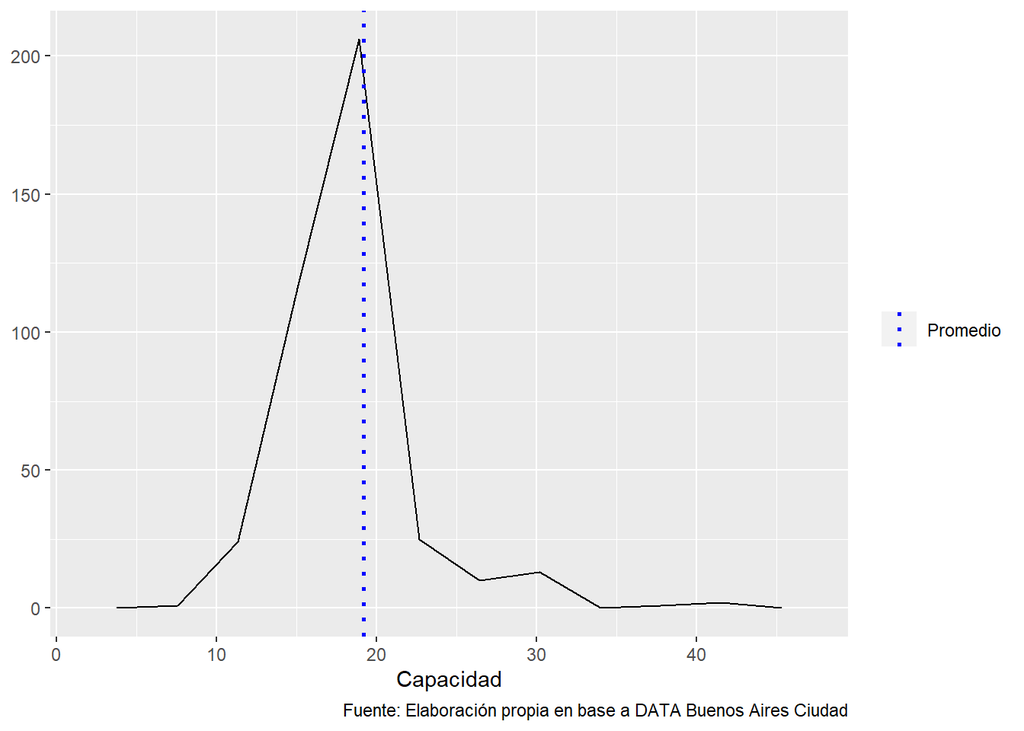

```r
ggplot(estaciones, aes(x = capacidad)) +
  geom_freqpoly(bins=10) +
  geom_vline(aes(xintercept = mean(`capacidad`), color="Promedio") ,
             linetype="dotted",
             size= 1) +
  scale_color_manual(values = c("Promedio" = "blue")) +
  labs( y = NULL,
        x = "Capacidad",
        color = NULL,
        caption = "Fuente: Elaboración propia en base a DATA Buenos Aires Ciudad")
```

Ahora dividiremos las estaciones dependiente su capacidad y las refenciamos en un mapa de cordenadas

```r
estaciones <-  estaciones %>%
                mutate(capacidad_est =
                        case_when( capacidad < 17 ~ "Capacidad baja (de 10 a 16 bicicletas)",
                        capacidad < 24 ~ "Capacidad media (de 17 a 23 bicicletas)",
                        TRUE           ~ "Capacidad alta (24 bicicletas y más)"),
                       capacidad_est = factor(capacidad_est,
                                              levels = c("Capacidad alta (24 bicicletas y más)",
                                                         "Capacidad media (de 17 a 23 bicicletas)",
                                                         "Capacidad baja (de 10 a 16 bicicletas)")))
```

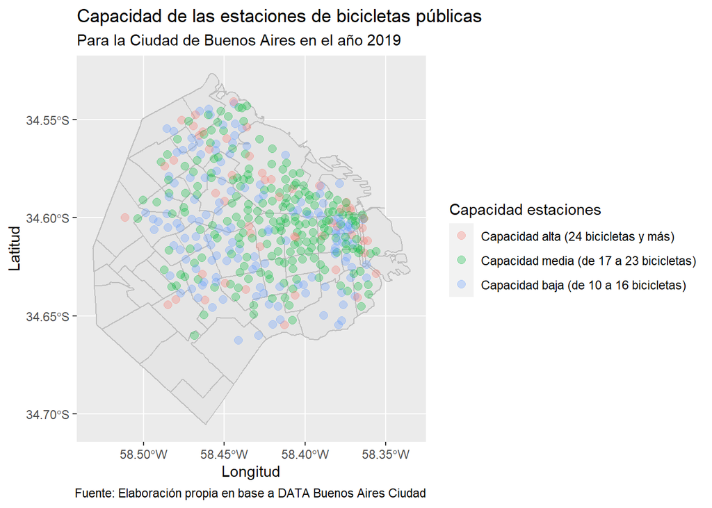

```r
puntos_estaciones <- ggplot() +
                     geom_sf(data = barrios,
                             color = "grey") +
                     geom_point(data= estaciones,
                                aes(x = lon, y = lat, color= capacidad_est),
                                size = 2.5 , alpha = .3) +
                     labs( title = "Capacidad de las estaciones de bicicletas públicas",
                          subtitle = "Para la Ciudad de Buenos Aires en el año 2019",
                          color = "Capacidad estaciones",
                          x = "Longitud",
                          y = "Latitud",
                          caption = "Fuente: Elaboración propia en base a DATA Buenos Aires Ciudad")
```

Podemos ajustar en base a la longitud y la latitud de las estaciones el zoom del mapa para tener una imagen más precisa.

```r
min_long <- min(estaciones$lon)
max_long <- max(estaciones$lon)
min_lat <- min(estaciones$lat)
max_lat <- max(estaciones$lat)
```

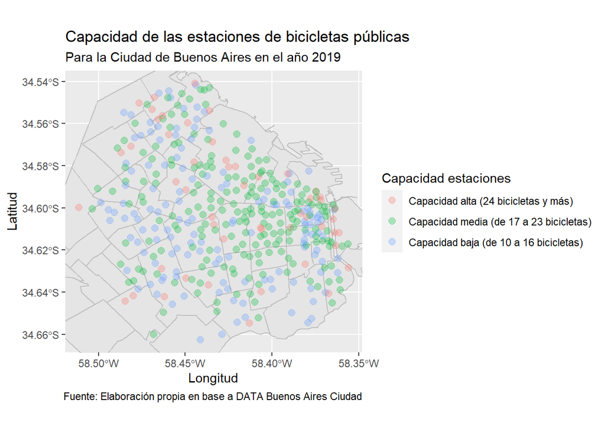

```r
puntos_estaciones +
  coord_sf(xlim = c(min_long, max_long),  ylim = c(min_lat, max_lat))
```

## Distribución por barrio

Para poder observar la distribución de estaciones por barrio hay que vincular el dataset “estaciones” al geojson “barrios” a través de un join espacial:

```r
# transformar el dataset en un objeto espacial
estaciones_obj <- st_as_sf(estaciones,
                            coords = c("lon","lat"),
                           crs = 4326)
# realizar el join y guardarlo en el objeto barrio_summary
barrio_summary <- barrios %>%
                  mutate(cantidad_estaciones = lengths(st_intersects(., estaciones_obj)),
                         AREA = round(AREA/1000000,2))
```

Ahora sí podemos mapear la distribución :

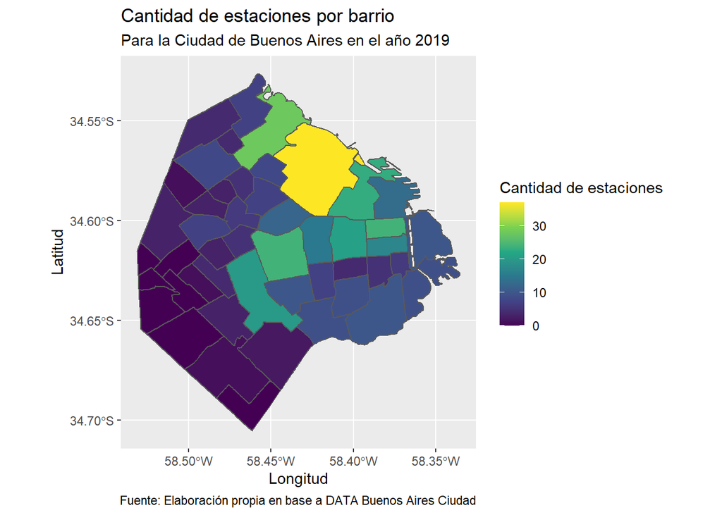

```r
ggplot() +
  geom_sf(data = barrio_summary,aes(fill = cantidad_estaciones))  +
  scale_fill_viridis_c()+
  labs(title = "Cantidad de estaciones por barrio",
       subtitle = "Para la Ciudad de Buenos Aires en el año 2019",
       fill = "Cantidad de estaciones",
       x = "Longitud",
       y = "Latitud",
       caption = "Fuente: Elaboración propia en base a DATA Buenos Aires Ciudad")
```

Lo que nos muesta el mapa es que la mayor cantidad de estaciones de concentrar en los barrios del noreste y el centro de la ciudad, siendo Palermo el barrio con más estaciones. Tambien se observa que los barrios del sudoeste tiene muy pocas o ninguna estación.

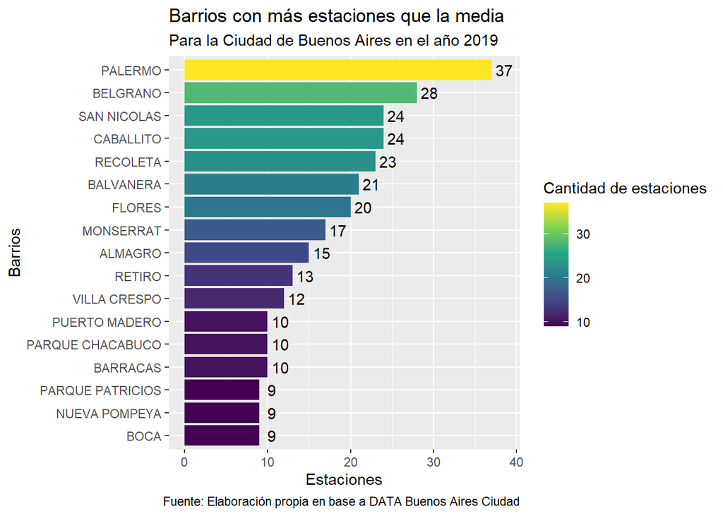

```r
barrio_summary %>%
filter(cantidad_estaciones > mean(cantidad_estaciones)) %>%
 ggplot(aes(x =reorder(BARRIO, cantidad_estaciones),
            y = cantidad_estaciones,
            fill = cantidad_estaciones,
            label = cantidad_estaciones)) +
  geom_col() +
  geom_text(nudge_y = 1.5) +
  coord_flip() +
  scale_fill_viridis_c()+
  labs(title = "Barrios con más estaciones que la media",
       subtitle = "Para la Ciudad de Buenos Aires en el año 2019",
       fill = "Cantidad de estaciones",
       x = "Barrios",
       y = "Estaciones",
       caption = "Fuente: Elaboración propia en base a DATA Buenos Aires Ciudad")
```

### Hipotesis

Nuestra hipotesis es que dicha distribución se relaciona con la población de los barios, por lo tanto suponemos que a mayor población mayor es la cantidad de estaciones.

Para ello Primero hay que calcular la densidad poblacional de cada barrio, utilizando datos de radios censales agrupados por el barrio :

```r
poblacion <-  read_csv("datos/pob barrios de caba.csv")
poblacion <-  poblacion %>%
              mutate(  BARRIO = stri_trans_general(str = `Localidad`,id = "Latin-ASCII"),
                       BARRIO = toupper(BARRIO),
                       BARRIO = case_when(BARRIO == "LA BOCA" ~ "BOCA",
                                          BARRIO == "NUNEZ"~ "NUÑEZ",
                                          TRUE ~ BARRIO)) %>%
             select(BARRIO,`Total población`)
```

```r
barrio_summary <- barrio_summary %>%
                  inner_join(.,poblacion, by = "BARRIO") %>%
                  mutate(densidad = trunc(`Total población`/AREA))
```

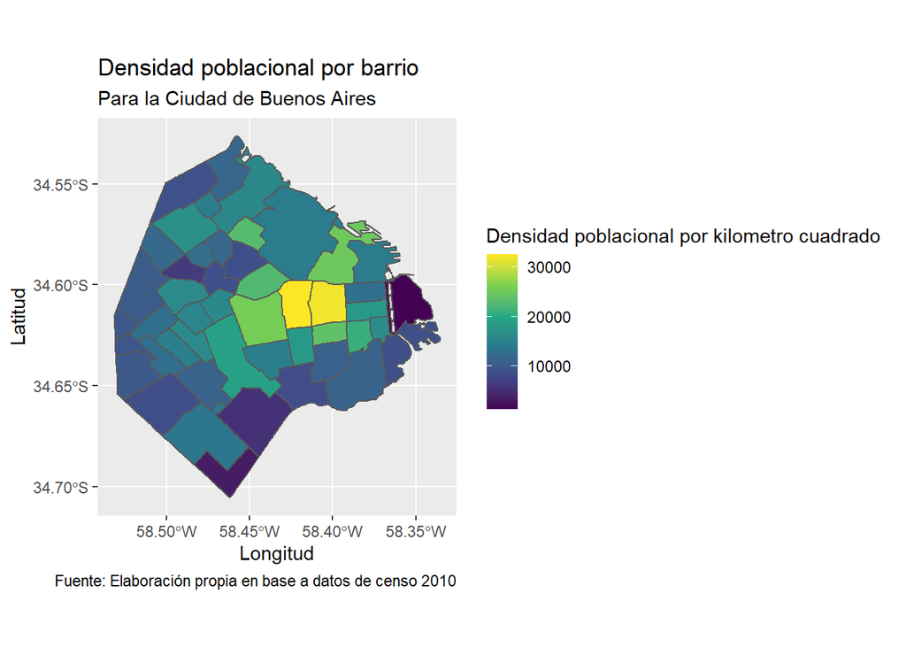

```r
ggplot() +
  geom_sf(data = barrio_summary,aes(fill = densidad))  +
  scale_fill_viridis_c()+
  labs(title = "Densidad poblacional por barrio",
       subtitle = "Para la Ciudad de Buenos Aires",
       fill = "Densidad poblacional por kilometro cuadrado ",
       x = "Longitud",
       y = "Latitud",
       caption = "Fuente: Elaboración propia en base a datos de censo 2010")
```

Se observa que los barrios del centro de la ciudad son los más densamente poblabados seguidos por los barrios del norte.

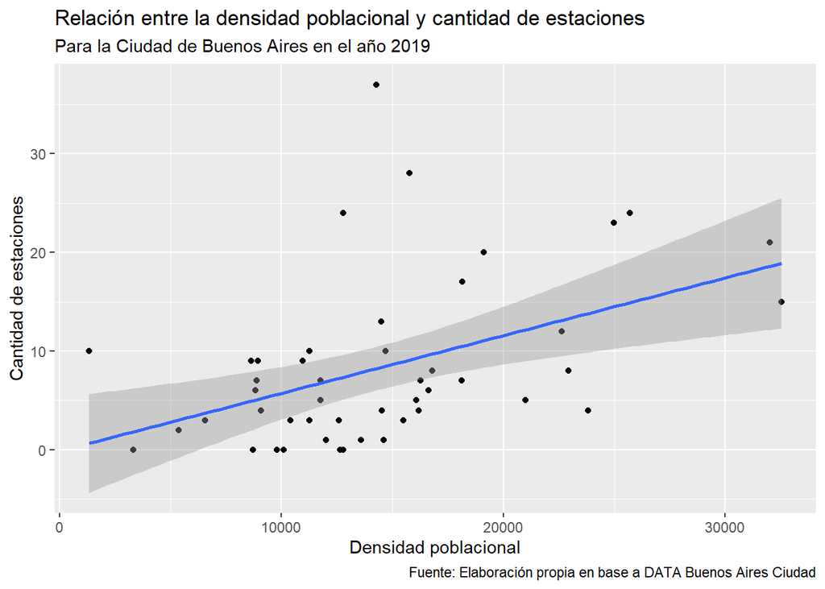

```r
ggplot(barrio_summary,aes(densidad,cantidad_estaciones )) +
  geom_point() +
  geom_smooth(method='lm') +
   labs(title = "Relación entre la densidad poblacional y cantidad de estaciones",
       subtitle = "Para la Ciudad de Buenos Aires en el año 2019",
       fill = "Densidad poblacional",
       x = "Densidad poblacional",
       y = "Cantidad de estaciones",
       caption = "Fuente: Elaboración propia en base a DATA Buenos Aires Ciudad")
```

Podemos observar que aunque existe una relación positiva entre densidad poblacional y cantidad de estaciones, la dispersión es muy alta por lo que no podemos asumir una relación directa entre las dos variables. Los barrios con mayor cantidad de estaciones no son los más densamente poblados (Almagro y Balvanera), dicho hallazgo se puede atribuir a que las estaciones se colocan en función de otras variables como pueden ser la cantidad de parques o las actividades económicas preponderantes.

### Uso estaciones

El dataset “uso_estaciones” está compuesto por 107.177 filas que describen el estado de las estaciones a lo largo de un día en terminos de bicicletas y espacios disponibles asi como también su estado.

```r
head(uso_estaciones,20)
```

|  | id_estacion | bicis_disponibles | bicis_rotas | espacios_disponibles | espacios_rotos | tiempo | hora |
| --- | --- | --- | --- | --- | --- | --- | --- |
| 1 | 254 | 2 | 2 | 12 | 1 | 2019-07-24T00:00:00Z | 0 |
| 2 | 254 | 1 | 2 | 13 | 0 | 2019-07-24T00:05:00Z | 0 |
| 3 | 254 | 4 | 2 | 10 | 0 | 2019-07-24T00:10:00Z | 0 |
| 4 | 254 | 6 | 2 | 8 | 0 | 2019-07-24T00:15:00Z | 0 |
| 5 | 254 | 6 | 2 | 8 | 0 | 2019-07-24T00:20:00Z | 0 |
| 6 | 254 | 3 | 2 | 11 | 0 | 2019-07-24T00:30:00Z | 0 |
| 7 | 254 | 3 | 2 | 11 | 0 | 2019-07-24T00:35:00Z | 0 |
| 8 | 254 | 2 | 2 | 12 | 0 | 2019-07-24T00:40:00Z | 0 |
| 9 | 254 | 2 | 2 | 12 | 0 | 2019-07-24T00:45:00Z | 0 |
| 10 | 254 | 2 | 2 | 12 | 0 | 2019-07-24T00:50:00Z | 0 |

[output cut: 10 more lines]

```r
sapply(uso_estaciones, function(columna) sum(is.na(columna)))
```

```
##          id_estacion    bicis_disponibles          bicis_rotas
##                    0                    0                    0
## espacios_disponibles       espacios_rotos               tiempo
##                    0                    0                    0
##                 hora
##                    0
```

En base al dataset podemos combinarlo con el geojson y analizar el uso de las bicicletas por barrio a lo largo del día:

```r
prueba <- estaciones_obj %>% st_join(.,barrios) %>%
                  select(id_estacion,BARRIO,capacidad) %>%
                  inner_join(uso_estaciones) %>%
                  group_by(BARRIO,hora) %>%
                    summarise(espacios = sum(espacios_disponibles),
                              capacidad = sum(capacidad),
                              promedio  = mean(espacios)) %>%
                    mutate(capacidad_uso  = promedio/capacidad * 100,
                           barrio = as.factor(BARRIO)) %>%
                    select(barrio,hora,capacidad_uso)
```

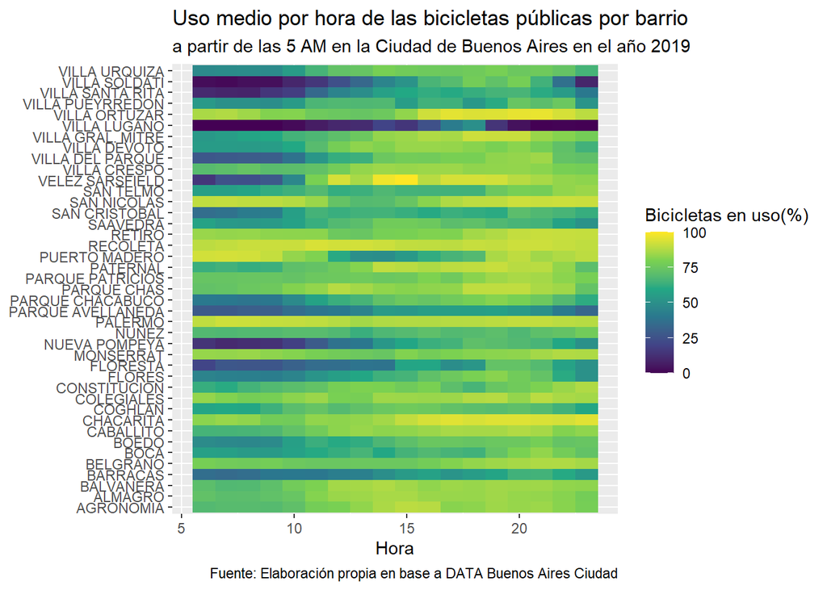

```r
                    prueba %>%  filter(!is.na(barrio)) %>%
                                filter(hora > 5) %>%
                    ggplot(aes(hora, barrio, fill= capacidad_uso)) +
                          geom_tile() +
                          scale_fill_viridis_c()+
     labs(title = "Uso medio por hora de las bicicletas públicas por barrio",
       subtitle = "a partir de las 5 AM en la Ciudad de Buenos Aires en el año 2019",
       fill = "Bicicletas en uso(%)",
       x = "Hora",
       y = NULL,
       caption = "Fuente: Elaboración propia en base a DATA Buenos Aires Ciudad")
```

## viajes en el año

```r
viajes <-  read.csv(file = "datos/recorridos-realizados-2019/recorridos-realizados-2019.csv")
```

el dateset recorridos-realizados-2019.csv tiene la información de todos los viajes que se hicieron en el 2019 siento un total de 6.275.957.

```r
head(viajes,20)
```

|  | id_recorrido | duracion_recorrido | fecha_origen_recorrido | id_estacion_origen | nombre_estacion_origen | direccion_estacion_origen | long_estacion_origen | lat_estacion_origen | fecha_destino_recorrido | id_estacion_destino | nombre_estacion_destino | direccion_estacion_destino | long_estacion_destino | lat_estacion_destino | id_usuario | modelo_bicicleta |
| --- | --- | --- | --- | --- | --- | --- | --- | --- | --- | --- | --- | --- | --- | --- | --- | --- |
| 1 | 2278BAEcobici | 1405 | 2019-02-25 18:50:48 UTC | 2BAEcobici | 002 - Retiro I | Ramos Mejia, Jose Maria, Dr. Av. & Del Libertador Av. | -58.37472 | -34.59242 | 2019-02-25 19:14:13 UTC | 1BAEcobici | ERRONEA | Av. Pres. Figueroa Alcorta 2120 | -58.00000 | -34.58381 | 2132BAEcobici | ICONIC |
| 2 | 2164BAEcobici | 3120 | 2019-02-25 18:22:46 UTC | 2BAEcobici | 002 - Retiro I | Ramos Mejia, Jose Maria, Dr. Av. & Del Libertador Av. | -58.37472 | -34.59242 | 2019-02-25 19:14:46 UTC | 49BAEcobici | 049 - 33 Orientales | Constitucion & Treinta Y Tres Orientales | -58.42261 | -34.62905 | 4610BAEcobici | ICONIC |
| 3 | 1616BAEcobici | 706 | 2019-02-25 14:59:51 UTC | 2BAEcobici | 002 - Retiro I | Ramos Mejia, Jose Maria, Dr. Av. & Del Libertador Av. | -58.37472 | -34.59242 | 2019-02-25 15:11:37 UTC | 1BAEcobici | ERRONEA | Av. Pres. Figueroa Alcorta 2120 | -58.00000 | -34.58381 | 5083BAEcobici | ICONIC |
| 4 | 2035BAEcobici | 2440 | 2019-02-25 17:50:08 UTC | 8BAEcobici | 008 - Congreso | Cevallos, Virrey& Yrigoyen, Hipolito Av. | -58.38934 | -34.60942 | 2019-02-25 18:30:48 UTC | 1BAEcobici | ERRONEA | Av. Pres. Figueroa Alcorta 2120 | -58.00000 | -34.58381 | 1547BAEcobici | ICONIC |
| 5 | 2792BAEcobici | 1846 | 2019-02-25 23:39:28 UTC | 8BAEcobici | 008 - Congreso | Cevallos, Virrey& Yrigoyen, Hipolito Av. | -58.38934 | -34.60942 | 2019-02-26 00:10:14 UTC | 49BAEcobici | 049 - 33 Orientales | Constitucion & Treinta Y Tres Orientales | -58.42261 | -34.62905 | 6482BAEcobici | ICONIC |
| 6 | 2338BAEcobici | 975 | 2019-02-25 19:12:36 UTC | 9BAEcobici | 009 - Parque Las Heras | 2300 Diaz, Cnel. Av. & French | -58.40774 | -34.58544 | 2019-02-25 19:28:51 UTC | 198BAEcobici | ArmazÃ©m | Armazem | -58.38000 | -34.57000 | 3404BAEcobici | ICONIC |
| 7 | 2785BAEcobici | 526 | 2019-02-25 23:33:33 UTC | 9BAEcobici | 009 - Parque Las Heras | 2300 Diaz, Cnel. Av. & French | -58.40774 | -34.58544 | 2019-02-25 23:42:19 UTC | 1BAEcobici | ERRONEA | Av. Pres. Figueroa Alcorta 2120 | -58.00000 | -34.58381 | 5037BAEcobici | ICONIC |
| 8 | 2779BAEcobici | 2759 | 2019-02-25 23:28:16 UTC | 9BAEcobici | 009 - Parque Las Heras | 2300 Diaz, Cnel. Av. & French | -58.40774 | -34.58544 | 2019-02-26 00:14:15 UTC | 49BAEcobici | 049 - 33 Orientales | Constitucion & Treinta Y Tres Orientales | -58.42261 | -34.62905 | 6422BAEcobici | ICONIC |
| 9 | 2364BAEcobici | 779 | 2019-02-25 19:21:38 UTC | 14BAEcobici | 014 - Pacifico | Santa Fe Av. & Bullrich, Int. Av. | -58.42639 | -34.57742 | 2019-02-25 19:34:37 UTC | 101BAEcobici | 101 - Fitz Roy | Fitz Roy 1092 & Loyola | -58.44244 | -34.58919 | 4223BAEcobici | ICONIC |
| 10 | 1449BAEcobici | 1746 | 2019-02-25 13:26:49 UTC | 14BAEcobici | 014 - Pacifico | Santa Fe Av. & Bullrich, Int. Av. | -58.42639 | -34.57742 | 2019-02-25 13:55:55 UTC | 1BAEcobici | ERRONEA | Av. Pres. Figueroa Alcorta 2120 | -58.00000 | -34.58381 | 4788BAEcobici | ICONIC |

[output cut: 10 more lines]

## Hipótesis

los usuarios del sistema realizan más viajes en los meses más calidos ya que el clima propicia mejores condiciones para andar en bicicleta.

```r
viajes <-  viajes %>%
  mutate(mes = month(fecha_origen_recorrido),
         mes = case_when(mes == 1 ~ "enero",
                         mes == 2 ~ "febrero",
                         mes == 3 ~ "marzo",
                         mes == 4 ~ "abril",
                         mes == 5 ~ "mayo",
                         mes == 6 ~ "junio",
                         mes == 7 ~ "julio",
                         mes == 8 ~ "agosto",
                         mes == 9 ~ "septiembre",
                         mes == 10 ~ "octubre",
                         mes == 11 ~ "noviembre",
                         mes == 12 ~ "diciembre"),
         mes = factor(mes, levels = c("enero","febrero","marzo",
                                      "abril","mayo","junio",
                                      "julio","agosto","septiembre",
                                      "octubre","noviembre","diciembre")))
```

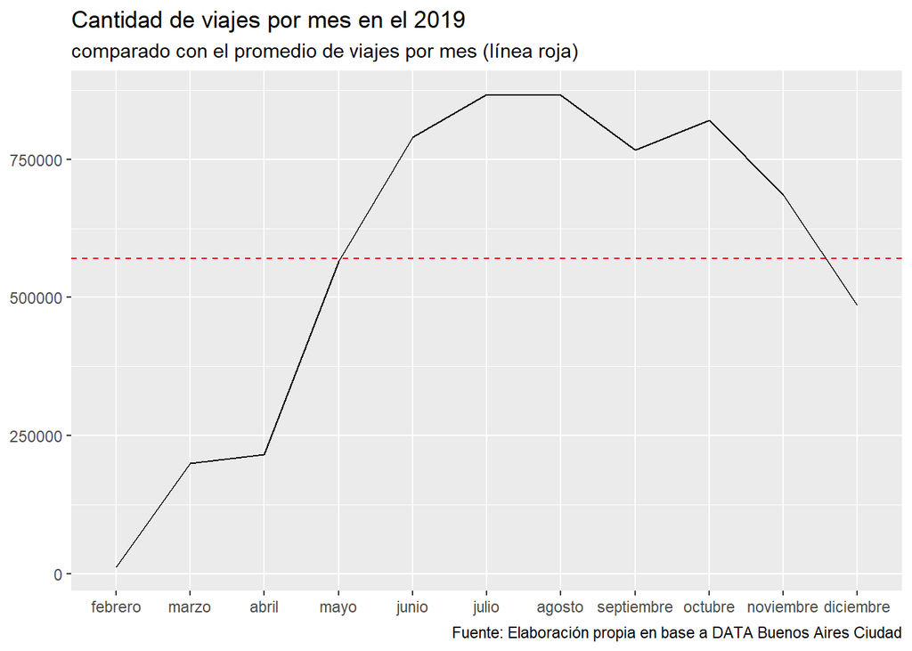

```r
 viajes %>% group_by(mes) %>%
  summarise(cantidad_viajes = n()) %>%
ggplot(data=. ,aes(x=mes,y=cantidad_viajes, group = 1)) +
  geom_line()+
  geom_hline(aes(yintercept=mean(cantidad_viajes)), linetype="dashed", color = "red")+
  labs(title = "Cantidad de viajes por mes en el 2019 ",
       subtitle = "comparado con el promedio de viajes por mes (línea roja)",
       x = NULL,
       y = NULL,
       caption = "Fuente: Elaboración propia en base a DATA Buenos Aires Ciudad")
```

Analizando el gráfico, en principio, podemos observar que la hipótesis queda descartada ya que en todo el invierno(junio,julio,agosto y septiembre) la cantidad de viajes está por arriba del promedio y es julio el mes con más viajes de todo el año.

```r
viajes %>% group_by(mes) %>%
  summarise(cantidad_viajes = n()) %>%
  arrange(desc(cantidad_viajes))
```

| mes | cantidad_viajes |
| --- | --- |
| julio | 867391 |
| agosto | 866390 |
| octubre | 821398 |
| junio | 790401 |
| septiembre | 767041 |
| noviembre | 685282 |
| mayo | 565357 |
| diciembre | 485131 |
| abril | 216080 |
| marzo | 200100 |

[output cut: 1 more lines]